# Algorithm Aversion

Kopkow, Angermaier, Rohrer, Sonnleitner

February 2022

# Motivation: Erwin

# Data processing: Mathias

```r
library(tidyverse)
library(tidytext)
library(textdata)
library(dplyr)
library(vader)
library(academictwitteR)
library(data.table)
library(readr)
```

used libraries

```r
listofdfs <- list()

#data group for cummulated dataframe

for (i in c(7:13)){
  alg.data %>%
    filter(alg.data[,i]>=1)%>%
    mutate(Topic = colnames(alg.data)[i], VADERclass=as.factor(VADERclass))%>%
    group_by(Year,Topic,VADERclass, .drop=FALSE)%>%
    summarise(Sent = n(), .groups = "drop") ->listofdfs[[i]]
}
summ.cumm <- bind_rows(listofdfs)


#adds percentage to cummulated DF
summ.cumm <-
  summ.cumm %>%
  group_by(Topic, Year) %>%
  mutate(All = sum(Sent),percent=(100*Sent/All))

summ.cumm
```

```
## # A tibble: 324 × 6
## # Groups:   Topic, Year [84]
##     Year Topic    VADERclass  Sent   All percent
##    <dbl> <chr>    <fct>      <int> <int>   <dbl>
##  1  2010 Business Aversive       2   297   0.673
##  2  2010 Business Negative      14   297   4.71
##  3  2010 Business Neutral      226   297  76.1
##  4  2010 Business Positive      55   297  18.5
##  5  2011 Business Aversive       7   337   2.08
##  6  2011 Business Negative      17   337   5.04
##  7  2011 Business Neutral      217   337  64.4
##  8  2011 Business Positive      96   337  28.5
##  9  2012 Business Aversive       4   357   1.12
## 10  2012 Business Negative      36   357  10.1
## # … with 314 more rows
```

```r
#data group for topic oriented dataframe

listofdfs <- list()

for (i in c(7:13)){
  alg.data %>%
    filter(alg.data[,i]>=1)%>%
    mutate(Topic = colnames(alg.data)[i])%>%
    group_by( VADERclass, Topic) %>%
    summarise(Sent = n()) ->listofdfs[[i]]
}
summ.topic <- bind_rows(listofdfs)

#adds percentage to topicwise DF
summ.topic<-
  summ.topic %>%
  group_by(Topic) %>%
  mutate(All = sum(Sent),percent=(100*Sent/All))


head(summ.topic)
```

```
## # A tibble: 6 × 5
## # Groups:   Topic [2]
##   VADERclass Topic         Sent   All percent
##   <chr>      <chr>        <int> <int>   <dbl>
## 1 Aversive   Business        73  3928    1.86
## 2 Negative   Business       373  3928    9.50
## 3 Neutral    Business      2165  3928   55.1
## 4 Positive   Business      1317  3928   33.5
## 5 Aversive   Social.Media  1601 43621    3.67
## 6 Negative   Social.Media  5918 43621   13.6
```

```r
#--------------Test wordgroups---------------------
listofdfs <- list()


for (i in c(7:13)){
  alg.data %>%
    filter(alg.data[,i]>=1)%>%
    mutate(Topic = colnames(alg.data)[i])%>%
    sample_n(size = 20)%>%
  group_by( VADERclass, Topic)  ->listofdfs[[i]]
}
Wordgrouptest<- bind_rows(listofdfs)
```

# Analysis

## Progression over the years

The diagram shows the percentage progression of the results of the sentiment analysis of tweets over the years 2010 to 2021. Values between 0.3 and -0.3 were classified as neutral. As positive between 0.3 and 1, as negative between -0.3 and -0.7 and finally as aversive values between -0.7 and -1. A total of 143271 tweets were analyzed. The fewest tweets were aversive and most were neutral since all tweets not evaluated in the sentiment analysis are classified as neutral.

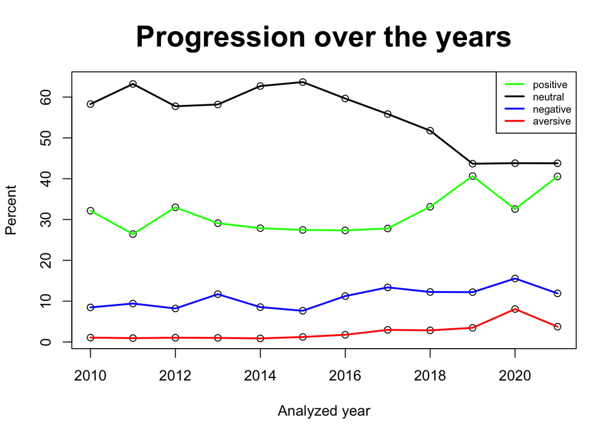

Over time, the number of neutral tweets decreases. In 2010, there were 6934 tweets and 58.3%. In 2015, the most neutral tweets were posted with an absolute of 7641 tweets and 63.8% posted. In 2019 the fewest mi 5241 and 43.7% were posted. 2021 total 5254 which is 43.8%. The last 3 years the number of neutral tweets remained at the same level.

An increasing trend can be seen in the number of positive tweets. In 2010, there were 3827 tweets and 32.2%. In 2019, the most positive tweets were posted with absolute 4878 tweets and 40.7% posted. In 2011 the least mi 3171 and 26.7% were posted. 2021 total 4868 which is 40.6%. The last 3 years the number of positive tweets remained high, with a bump in 2020 with 3908 and 32.6%.

The aversive tweets behave similarly to the negative tweets 2011 113 0.95% there were the fewest were 2014 105 and 0.88% with the most there were 2020 968 8.1% and 2021 there were 3.7% and 449 tweets.